# R for developers

Steph Locke

2017-04-20

# Steph Locke | Who I am

- Data specialist
- Principal Consultant @ Mango Solutions
- github: stephlocke/Rtraining
- blog: itsalocke.com
- t: [@stefflocke](http://twitter.com/stefflocke)

# R

# R | A brief history

- S, born 1976 in Bell Laboratories
- R, born 1997 in a uni in NZ
- R Foundation, born 2002
- R Consortium, born 2015
- R now ranked 6th most popular language by IEEE

# R | Why use it?

- For the stats
- For the cross-platform capability
- For the reproducibility
- For the time it can save
- For the flexibility
- For the money

# R | Why not Python?

Firstly, Python is a valid way to go. There are number of really good libraries out there for number crunching etc. and it is a well written language with few “quirks”

Secondly, why R is my preference:

- Easy install
- Strong community base
- Data focused
- Very flexible and extendable
- It’s the favourite to win

But… “production” code can be faster in Python

# R fundamentals

# Basics

```r
# Define a variable
a<-25

# Call a variable
a
```

```
## [1] 25
```

```r
# Do something to it
a+1
```

```
## [1] 26
```

# Data types | p1

```r
# Numeric
25
```

```
## [1] 25
```

```r
# Character
"25"
```

```
## [1] "25"
```

```r
# Logical
TRUE
```

```
## [1] TRUE
```

# Data types | p2

```r
# Dates
as.Date("2015-08-05")
```

```
## [1] "2015-08-05"
```

```r
as.POSIXct("2015-08-01")
```

```
## [1] "2015-08-01 UTC"
```

# Data types | p3

```r
# Factor
as.numeric(factor("25"))
```

```
## [1] 1
```

```r
as.character(factor("25"))
```

```
## [1] "25"
```

# Constructs | p1

```r
# Vector
a<-c(25, 30)

# Matrix
matrix(a)
```

```
##      [,1]
## [1,]   25
## [2,]   30
```

# Constructs | p2

```r
# Data frame
data.frame(a,b=a/5,c=LETTERS[1:2])
```

```
##    a b c
## 1 25 5 A
## 2 30 6 B
```

```r
# List
list(vector=a, matrix=matrix(a))
```

```
## $vector
## [1] 25 30
##
## $matrix
##      [,1]
## [1,]   25
## [2,]   30
```

# Subsetting | Vectors

```r
a <- sample(1:20, size = 5, replace = TRUE) # setup
a # visual check
```

```
## [1]  3 18 15  7 12
```

```r
a[1:2] # row numbers
```

```
## [1]  3 18
```

```r
a[a<=10] # value filters
```

```
## [1] 3 7
```

# Subsetting | Data.frames p1

```r
df <- data.frame(a=1:10, b = LETTERS[1:5]) # setup
df[1:2,] # row numbers
```

```
##   a b
## 1 1 A
## 2 2 B
```

```r
df[df$a<2,] # value filters
```

```
##   a b
## 1 1 A
```

# Subsetting | Data.frames p2

```r
df[df$a<3,1] # column filter
```

```
## [1] 1 2
```

```r
df[df$a<3,1, drop=FALSE] # column filter (keep data.frame)
```

```
##   a
## 1 1
## 2 2
```

# Functions

```r
# Define a function
showAsPercent<-function(x) {
  paste0(round(x*100 ,0) ,"%")
}

# Call a function
showAsPercent(0.1)
```

```
## [1] "10%"
```

# Extending R

```r
# Get a package
install.packages("caret")

# Activate a package
library(caret)
```

# What does R look like? | OO

```r
# Orig OO (s3): cyclismo.org/tutorial/R/s3Classes.html
library(R6)
Loan<-R6Class("Loan",
              public=list(term=NA
                         ,initialize=function(term){
                           if(!missing(term)){
                              self$term<-term
                              }}
                         ,extendBy=function(ext){
                            self$term<-self$term+ext
                            }))
```

# What does R look like? | OO

```r
acc<-Loan$new(36)
acc$extendBy(6)
acc$term
```

```
## [1] 42
```

# Building up an R script

# Commands | magrittr

magrittr allows you to pass one thing into another instead of writing lots of brackets

```r
library(magrittr)
# Typical
pairs(iris)
pairs(tail(iris))
pairs(tail(iris,nrow(iris)/5))

# Pipe
iris %>% pairs
iris %>% tail %>% pairs
iris %>% {tail(.,nrow(.)/5)} %>% pairs
```

# Commands | dplyr

Use `dplyr` to transform your datasets

```r
library(dplyr)
iris %>%
  filter(Petal.Width<2) %>%
  group_by(Species) %>%
  summarise_each(funs(mean))
```

```
## # A tibble: 3 × 5
##      Species Sepal.Length Sepal.Width Petal.Length Petal.Width
##       <fctr>        <dbl>       <dbl>        <dbl>       <dbl>
## 1     setosa     5.006000    3.428000      1.46200    0.246000
## 2 versicolor     5.936000    2.770000      4.26000    1.326000
## 3  virginica     6.338095    2.790476      5.32381    1.761905
```

# Read data | CSV & Excel

```r
library(readr)
OrderData<-read_csv("Order.csv")

library(readxl)
OrderData<-read_sheet("Order.xlsx","Orders")
```

# Read data | Databases

```r
library(RODBC)
azure <- odbcDriverConnect(
  "Driver={SQL Server Native Client 11.0};
  Server=mhknbn2kdz.database.windows.net;
  Database=AdventureWorks2012;
  Uid=sqlfamily;
  Pwd=sqlf@m1ly;")

Order    <- sqlQuery( azure,
            "SELECT * FROM [Sales].[SalesOrderHeader]")
```

# Write data | CSV

This is easiest and most portable option

```r
write.csv(iris,"iris.csv", row.names = FALSE)
```

# Script best practices

- Make sure to declare packages using `library()` at the top of the script
- Label sections of work using `# ---- SectionName ----` to allow you to pick up the code into a LaTeX or markdown doc later
- Never delete <- always make new objects with modifications
- If comfortable with coding, or have a lot of data to process use `data.table` over `dplyr`
- Try to do all data manipulation at the top of the script
- Reuse your code by writing functions for anything you do frequently

# “Best” practices

# Charts

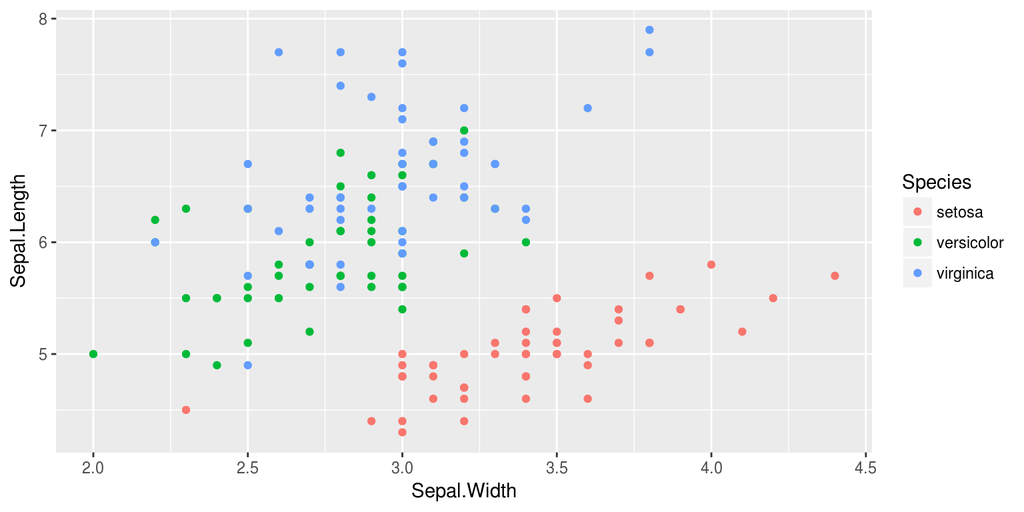

```r
library(ggplot2)
ggplot(data=iris,
       aes(x=Sepal.Width, y=Sepal.Length, colour=Species)) +
  geom_point()
```

# Documentation

Document as you go!

- Use markdown to use a light syntax for integrating your code and commentary
- Use LaTeX for finer level of control on output layout
- Use these instead of Excel or Word so that a change in assumption means updating the code and re-running the doc
- Load your main R file up and use the labels from `# ---- SectionName ----` to save repetition
- Present in HTML, slide decks, PDF, Word at the click of a button

# Interactive reports

Consider doing a `shiny` application that explores the data and findings

# Workflow best practices

- Focus on working code & documentation
- Use source control (github)
- Write tests (`assertive`, `assertthat`, `testthat`)
- Regularly visualise (`ggplot2`)
- Do code reviews
- Modularise
- Use Rstudio
- Consider structuring as a package

# Next steps

# Find out more

### Online

- Modern R [DataCamp](http://datacamp.com)
- Statistics R [Coursera](https://www.coursera.org/specialization/jhudatascience)
- [R-bloggers](http://www.r-bloggers.com/)
- [Advanced R programming](http://adv-r.had.co.nz/)
- [Writing R packages](http://r-pkgs.had.co.nz/)

### In-person

- R user groups e.g. [LondonR](http://www.londonr.org/)
- Conferences e.g. [EARL](http://www.earl-conference.com/), [SQL Relay](http://sqlrelay.co.uk)

# Get this presentation

This presentation is available on github.com/stephlocke/Rtraining. All the code is available for you to take a copy and play with to help you learn on the go.

If you have any questions, contact me!

itsalocke.com | github.com/StephLocke | [@SteffLocke](https://twitter.com/stefflocke)